# Pharmacy, Dispensing and Responsibility

Adam La Caze

March 2022

## Objectives

1. Appreciate, and start to develop the attitudes of a pharmacist, especially with respect to dispensing
2. Develop a systematic process to dispensing

## Discussion

What is the role of the pharmacist?

What feedback do preceptors give about students and interns?

## Key concepts

1. Pharmacists take responsibility for getting dispensing *right*
2. The overall aim is *always* improving patient outcomes
3. The challenge of dispensing is *always* and *efficiently* ensuring a rather long list of easy things are done correctly and well (while not losing sight that the objective is to improve patient outcomes)

## Examples

- It is late Saturday afternoon, Jonathan has just been discharged from the local hospital following a knee replacement. He has a discharge script for his pain medicines, but no script for his anticonvulsant. You can’t get in touch with the hospital doctor or his usual GP.

## Examples

A man’s daughter comes to the pharmacy with a prescription for methotrexate 2.5mg, 30.

The directions were to take 2 daily for a psoriasis flare up.

What do you see?

## Examples

- Mrs Zhang presents with a prescription for Rhinocort Nasal Spray 64mcg/dose 120 doses
- Mrs Robyn Woodward presents with a prescription for her antihypertensive and antidepressant
- You are a locum in a community pharmacy that looks after a large number of methadone patients

[figure not shown]

Back

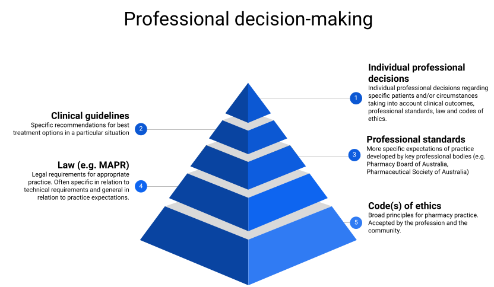